# Module 1 - Peer reviewed

### Outline:

1. To assess your knowledge of ANOVA/ANCOVA models
2. To apply your understanding of these models to a real-world datasets

General tips:

1. Read the questions carefully to understand what is being asked.
2. This work will be reviewed by another human, so make sure that you are clear and concise in what you are attempting to explain or answer.

```python
# Load Required Packages
library(tidyverse)
library(ggplot2)
library(plyr)
library(dplyr)
```

### Problem #1: Simulate ANCOVA Interactions

In this problem, we will work up to analyzing the following model to show how interaction terms work in an ANCOVA model.

$$Y_i = \beta_0 + \beta_1 X + \beta_2 Z + \beta_3XZ + \varepsilon_i$$

This question is designed to enrich understanding of interactions in ANCOVA models. There is no additional coding required for this question, however we recommend messing around with the coefficents and plot as you see fit. Ultimately, this problem is graded based on written responses to questions asked in part **(a)** and **(b)**.

To demonstrate how interaction terms work in an ANCOVA model, let's generate some data. First, we consider the model

$$Y_i = \beta_0 + \beta_1 X + \beta_2 Z + \varepsilon_i$$

where $X$ is a continuous covariate, $Z$ is a dummy variable coding the levels of a two level factor, and $\varepsilon_i \overset{iid}{\sim} N(0,\sigma^2)$. We choose values for the parameters below (b0,...,b2).

A data.frame: 6 × 3

|  | x <dbl> | z <fct> | y <dbl> |
| --- | --- | --- | --- |
| 1 | 0.09159879 | 1 | 6.290179 |
| 2 | 1.96439135 | 1 | 10.168612 |
| 3 | 0.57805656 | 1 | 7.200027 |
| 4 | 0.03370108 | 0 | 1.289331 |
| 5 | 1.82614045 | 0 | 4.470862 |
| 6 | 0.71220319 | 0 | 2.485743 |

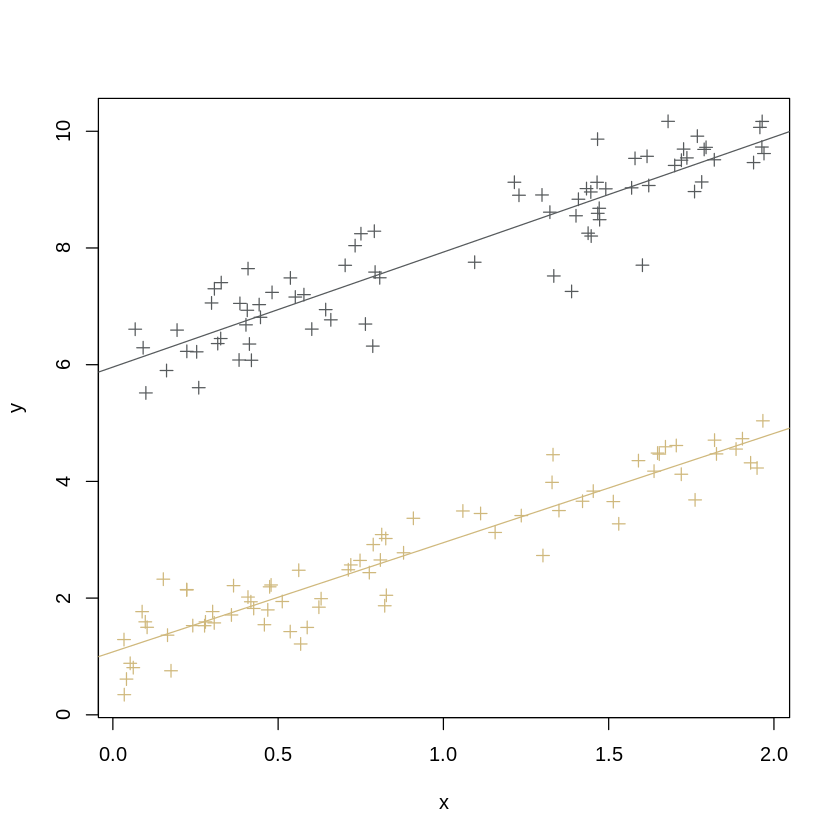

```python
rm(list = ls())
set.seed(99)

#simulate data
n = 150
# choose these betas
b0 = 1; b1 = 2; b2 = 5; eps = rnorm(n, 0, 0.5);
x = runif(n,0,2); z = runif(n,-2,2);
z = ifelse(z > 0,1,0);
# create the model:
y = b0 + b1*x + b2*z + eps
df = data.frame(x = x,z = as.factor(z),y = y)
head(df)

#plot separate regression lines
with(df, plot(x,y, pch = 3, col = c("#CFB87C","#565A5C")[z]))
abline(coef(lm(y[z == 0] ~ x[z == 0], data = df)), col = "#CFB87C")
abline(coef(lm(y[z == 1] ~ x[z == 1], data = df)), col = "#565A5C")
```

#### 1. (a) What happens with the slope and intercept of each of these lines?

In this case, we can think about having two separate regression lines--one for $Y$ against $X$ when the unit is in group $Z = 0$ and another for $Y$ against $X$ when the unit is in group $Z = 1$. What do we notice about the slope of each of these lines?

The slopes of each of the lines are forced to be equivalent by the structure of the model; each are governed solely by $\beta_1$ regardless of the value of the dummy variable **Z**. The intercept is different for each value of the dummy variable **Z**: When $Z = 0$, the intercept is given by just $\beta_0$, but when $Z = 1$ the intercept is given by $\beta_0 + \beta_2 $. With no interaction term present, we will see the same slope but different intercepts (for non-zero values of $\beta_2$).

#### 1. (b) Now, let's add the interaction term (let $\beta_3 = 3$). What happens to the slopes of each line now?

The model now is of the form:

$$Y_i = \beta_0 + \beta_1 X + \beta_2 Z + \beta_3XZ + \varepsilon_i$$

where $X$ is a continuous covariate, $Z$ is a dummy variable coding the levels of a two level factor, and $\varepsilon_i \overset{iid}{\sim} N(0,\sigma^2)$. We choose values for the parameters below (b0,...,b3).

A data.frame: 6 × 3

|  | x <dbl> | z <fct> | y <dbl> |
| --- | --- | --- | --- |
| 1 | 0.09159879 | 1 | 6.564975 |
| 2 | 1.96439135 | 1 | 16.061786 |
| 3 | 0.57805656 | 1 | 8.934197 |
| 4 | 0.03370108 | 0 | 1.289331 |
| 5 | 1.82614045 | 0 | 4.470862 |
| 6 | 0.71220319 | 0 | 2.485743 |

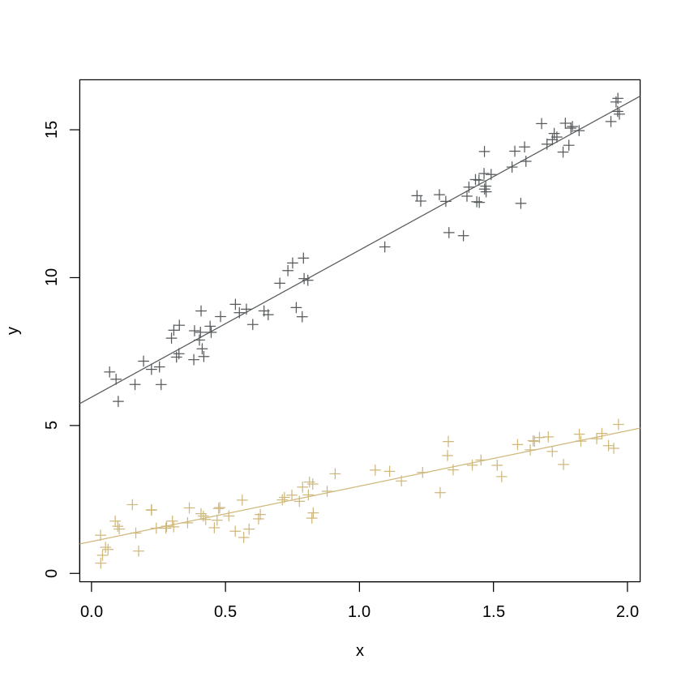

```python
#simulate data
set.seed(99)
n = 150
# pick the betas
b0 = 1; b1 = 2; b2 = 5; b3 = 3; eps = rnorm(n, 0, 0.5);

#create the model
y = b0 + b1*x + b2*z + b3*(x*z) + eps
df = data.frame(x = x,z = as.factor(z),y = y)
head(df)

lmod = lm(y ~ x + z, data = df)
lmodz0 = lm(y[z == 0] ~ x[z == 0], data = df)
lmodz1 = lm(y[z == 1] ~ x[z == 1], data = df)
# summary(lmod)
# summary(lmodz0)
# summary(lmodz1)

# lmodInt = lm(y ~ x + z + x*z, data = df)
# summary(lmodInt)

#plot separate regression lines
with(df, plot(x,y, pch = 3, col = c("#CFB87C","#565A5C")[z]))
abline(coef(lm(y[z == 0] ~ x[z == 0], data = df)), col = "#CFB87C")
abline(coef(lm(y[z == 1] ~ x[z == 1], data = df)), col = "#565A5C")
```

In this case, we can think about having two separate regression lines--one for $Y$ against $X$ when the unit is in group $Z = 0$ and another for $Y$ against $X$ when the unit is in group $Z = 1$. **What do you notice about the slope of each of these lines?**

With an interaction term added into the mix, we will now see a visual disparity in both the slope and the intercept of the regression lines. As before, when $Z = 0$, the intercept is given by just $\beta_0$ and when $Z = 1$ the intercept is given by $\beta_0 + \beta_2 $. The difference now is that when $Z = 0$, the slope is given by $\beta_1$ but when $Z = 1$ the slope is given by $(\beta_1 + \beta_3)$. This means that as long as $\beta_3$ is non-zero, the slopes of the two lines will not be exactly the same numerically.

## Problem #2

In this question, we ask you to analyze the `mtcars` dataset. The goal if this question will be to try to explain the variability in miles per gallon (mpg) using transmission type (am), while adjusting for horsepower (hp).

To load the data, use `data(mtcars)`

#### 2. (a) Rename the levels of am from 0 and 1 to "Automatic" and "Manual" (one option for this is to use the revalue() function in the plyr package). Then, create a boxplot (or violin plot) of mpg against am. What do you notice? Comment on the plot

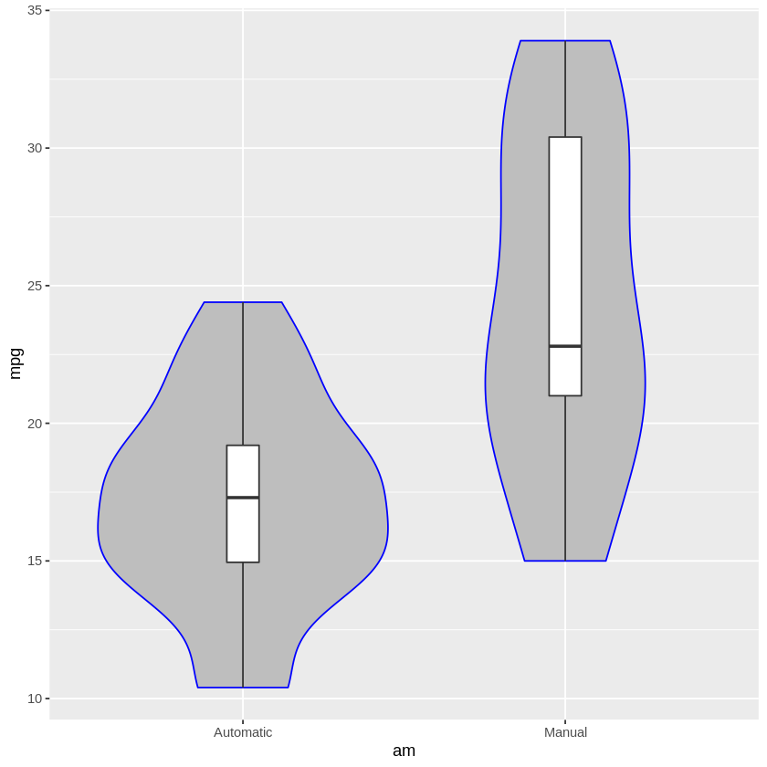

```python
data(mtcars)

#revalue(as.factor(mtcars$am), c("0" = "Automatic", "1" = "Manual"))
mtcars$am <- factor(mtcars$am)
mtcars$am <- revalue(mtcars$am, c("0" = "Automatic", "1" = "Manual"))

ggplot(mtcars, aes(x=mpg, y=am, group = am)) +
    geom_violin(fill='grey', color="blue") +
    geom_boxplot(width = 0.1) +
    coord_flip()
```

The cars with an automatic transmission have a much worse fuel efficiency on average than the cars with a manual transmission. The variability in the distribution of mpg for automatic transmission cars is lower than it is for cars in the manual transmission group. This provides graphical evidence that the type of tranmission in a car has an effect on the car's mpg.

#### 2. (b) Calculate the mean difference in mpg for the Automatic group compared to the Manual group.

```python
head(mtcars)

auto <- mean(mtcars$mpg[mtcars$am == "Automatic"])
auto

manual <- mean(mtcars$mpg[mtcars$am == "Manual"])
manual

difference <- manual - auto
difference
```

A data.frame: 6 × 11

|  | mpg <dbl> | cyl <dbl> | disp <dbl> | hp <dbl> | drat <dbl> | wt <dbl> | qsec <dbl> | vs <dbl> | am <fct> | gear <dbl> | carb <dbl> |
| --- | --- | --- | --- | --- | --- | --- | --- | --- | --- | --- | --- |
| Mazda RX4 | 21.0 | 6 | 160 | 110 | 3.90 | 2.620 | 16.46 | 0 | Manual | 4 | 4 |
| Mazda RX4 Wag | 21.0 | 6 | 160 | 110 | 3.90 | 2.875 | 17.02 | 0 | Manual | 4 | 4 |
| Datsun 710 | 22.8 | 4 | 108 | 93 | 3.85 | 2.320 | 18.61 | 1 | Manual | 4 | 1 |
| Hornet 4 Drive | 21.4 | 6 | 258 | 110 | 3.08 | 3.215 | 19.44 | 1 | Automatic | 3 | 1 |
| Hornet Sportabout | 18.7 | 8 | 360 | 175 | 3.15 | 3.440 | 17.02 | 0 | Automatic | 3 | 2 |
| Valiant | 18.1 | 6 | 225 | 105 | 2.76 | 3.460 | 20.22 | 1 | Automatic | 3 | 1 |

17.1473684210526

24.3923076923077

7.24493927125506

The mean difference in mpg between the Automatic and Manual groups is approximately 7.2449 mpg.

#### 2. (c) Construct three models:

1. An ANOVA model that checks for differences in mean mpg across different transmission types.
2. An ANCOVA model that checks for differences in mean mpg across different transmission types, adjusting for horsepower.
3. An ANCOVA model that checks for differences in mean mpg across different transmission types, adjusting for horsepower and for interaction effects between horsepower and transmission type.

**Using these three models, determine whether or not the interaction term between transmission type and horsepower is significant.**

```python
mod_1 <- lm(mpg ~ am, data = mtcars)
anova(mod_1)
#summary(mod_1)

mod_2 <- lm(mpg ~ am + hp, data = mtcars)
anova(mod_2)
sum_2 <- summary(mod_2)


mod_3 <- lm(mpg ~ am + hp + am:hp, data = mtcars)
anova(mod_3)
sum_3 <- summary(mod_3)

anova(mod_1, mod_2)
anova(mod_2, mod_3)
anova(mod_1, mod_3)
```

A anova: 2 × 5

|  | Df <int> | Sum Sq <dbl> | Mean Sq <dbl> | F value <dbl> | Pr(>F) <dbl> |
| --- | --- | --- | --- | --- | --- |
| am | 1 | 405.1506 | 405.15059 | 16.86028 | 0.0002850207 |
| Residuals | 30 | 720.8966 | 24.02989 | NA | NA |

A anova: 3 × 5

|  | Df <int> | Sum Sq <dbl> | Mean Sq <dbl> | F value <dbl> | Pr(>F) <dbl> |
| --- | --- | --- | --- | --- | --- |
| am | 1 | 405.1506 | 405.150588 | 47.87077 | 1.327227e-07 |
| hp | 1 | 475.4573 | 475.457311 | 56.17789 | 2.920375e-08 |
| Residuals | 29 | 245.4393 | 8.463424 | NA | NA |

A anova: 4 × 5

|  | Df <int> | Sum Sq <dbl> | Mean Sq <dbl> | F value <dbl> | Pr(>F) <dbl> |
| --- | --- | --- | --- | --- | --- |
| am | 1 | 4.051506e+02 | 4.051506e+02 | 4.622104e+01 | 2.196696e-07 |
| hp | 1 | 4.754573e+02 | 4.754573e+02 | 5.424188e+01 | 5.088357e-08 |
| am:hp | 1 | 5.251456e-03 | 5.251456e-03 | 5.991051e-04 | 9.806460e-01 |
| Residuals | 28 | 2.454340e+02 | 8.765501e+00 | NA | NA |

A anova: 2 × 6

|  | Res.Df <dbl> | RSS <dbl> | Df <dbl> | Sum of Sq <dbl> | F <dbl> | Pr(>F) <dbl> |
| --- | --- | --- | --- | --- | --- | --- |
| 1 | 30 | 720.8966 | NA | NA | NA | NA |
| 2 | 29 | 245.4393 | 1 | 475.4573 | 56.17789 | 2.920375e-08 |

A anova: 2 × 6

|  | Res.Df <dbl> | RSS <dbl> | Df <dbl> | Sum of Sq <dbl> | F <dbl> | Pr(>F) <dbl> |
| --- | --- | --- | --- | --- | --- | --- |
| 1 | 29 | 245.4393 | NA | NA | NA | NA |
| 2 | 28 | 245.4340 | 1 | 0.005251456 | 0.0005991051 | 0.980646 |

A anova: 2 × 6

|  | Res.Df <dbl> | RSS <dbl> | Df <dbl> | Sum of Sq <dbl> | F <dbl> | Pr(>F) <dbl> |
| --- | --- | --- | --- | --- | --- | --- |
| 1 | 30 | 720.8966 | NA | NA | NA | NA |
| 2 | 28 | 245.4340 | 2 | 475.4626 | 27.12124 | 2.811029e-07 |

The interaction term between transmission type and horsepower appears to be statistically insignificant, as the p-value for the F-test performed on the interaction term is 0.98. This p-value fails to reject the null hypothesis (the interaction term does not add sufficient value to the model to be included) at any reasonable alpha level ($\alpha <= 0.05$); the reduced model with no interaction term is the better model choice.

#### 2. (d) Construct a plot of mpg against horsepower, and color points based in transmission type. Then, overlay the regression lines with the interaction term, and the lines without. How are these lines consistent with your answer in (b) and (c)?

```
Call:
lm(formula = mpg ~ am + hp + am:hp, data = mtcars)

Residuals:
    Min      1Q  Median      3Q     Max
-4.3818 -2.2696  0.1344  1.7058  5.8752

Coefficients:
              Estimate Std. Error t value Pr(>|t|)
(Intercept) 26.6248479  2.1829432  12.197 1.01e-12 ***
amManual     5.2176534  2.6650931   1.958   0.0603 .
hp          -0.0591370  0.0129449  -4.568 9.02e-05 ***
amManual:hp  0.0004029  0.0164602   0.024   0.9806
---
Signif. codes:  0 ‘***’ 0.001 ‘**’ 0.01 ‘*’ 0.05 ‘.’ 0.1 ‘ ’ 1

Residual standard error: 2.961 on 28 degrees of freedom
Multiple R-squared:  0.782,	Adjusted R-squared:  0.7587
F-statistic: 33.49 on 3 and 28 DF,  p-value: 2.112e-09
```

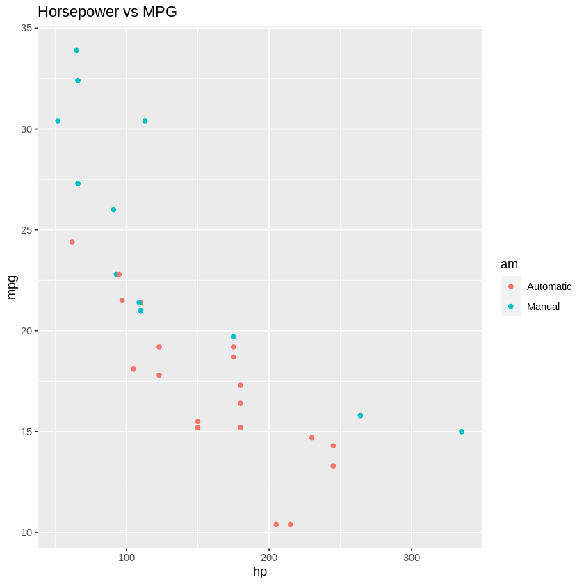

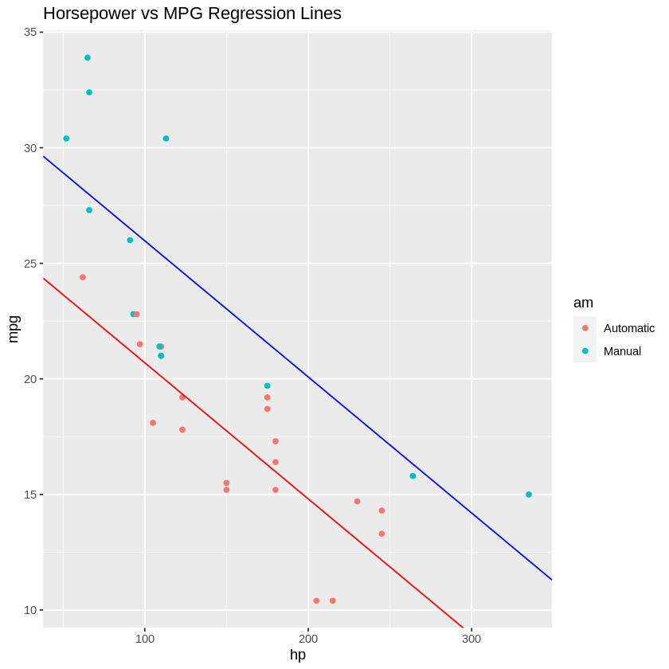

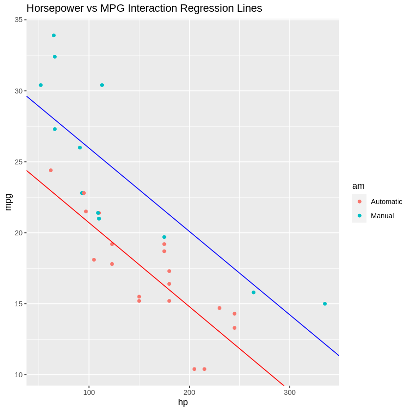

```python
simple <- ggplot(mtcars, aes(x=hp, y=mpg, color = am)) +
geom_point() +
labs(title = "Horsepower vs MPG")
simple

#sum_2
mod_2_int_auto <- sum_2$coefficients[1, 1]
mod_2_slope <- sum_2$coefficients[3, 1]
mod_2_int_man <- sum_2$coefficients[1, 1] + sum_2$coefficients[2, 1]

sum_3
mod_3_int_auto <- sum_3$coefficients[1, 1]
mod_3_slope_auto <- sum_3$coefficients[3, 1]
mod_3_int_man <- sum_3$coefficients[1, 1] + sum_3$coefficients[2, 1]
mod_3_slope_man <- sum_3$coefficients[3, 1] + sum_3$coefficients[4, 1]

no_interaction <- ggplot(mtcars, aes(x=hp, y=mpg, color = am)) +
geom_point() +
geom_abline(intercept = mod_2_int_auto, slope = mod_2_slope, col = "red") +
geom_abline(intercept = mod_2_int_man, slope = mod_2_slope, col = "blue") +
labs(title = "Horsepower vs MPG Regression Lines")
no_interaction


interaction <- ggplot(mtcars, aes(x=hp, y=mpg, color = am)) +
geom_point() +
geom_abline(intercept = mod_3_int_auto, slope = mod_3_slope_auto, col = "red") +
geom_abline(intercept = mod_3_int_man, slope = mod_3_slope_man, col = "blue") +
labs(title = "Horsepower vs MPG Interaction Regression Lines")
interaction

# with(mtcars, plot(hp,mpg, pch = 3, col = c("#CFB87C","#565A5C")[am]))
# abline(coef(lm(mpg[am == 'Manual'] ~ hp[am == 'Manual'], data = mtcars)), col = "#CFB87C")
# abline(coef(lm(mpg[am == 'Automatic'] ~ hp[am == 'Automatic'], data = mtcars)), col = "#565A5C")
```